# Glacierpoint - glom() Demo

v0.2.0 - last updated 2020/01/25

Andrew Brown; andrew.g.brown@usda.gov

In this demo, we use the *aqp* functions `glom()` and `profileApply()` to analyze a depth-subset of horizons from each profile in a *SoilProfileCollection*.

`glom()` returns the horizon(s) that intersect the specified depth [*z1*] or depth interval [*z1*, *z2*].

### Checking for cambic horizon criteria

First, the script queries components by component name, then gets records populated in the *Component Diagnostic Features* (`codiagfeatures`) table.

`glom()` is used to get all horizons that are *within the cambic depth range*. A custom function `has_sandy_cambic()` is defined to use `glom()` on individual profiles (`p`).

A regular expression pattern is used to check the `glom()`-ed horizon textures field (`p$texture`) for stratified and/or sandy texture classes that are *not* allowed in cambic horizons.

If either stratified or sandy textures are found, the function returns `TRUE` for that profile. Otherwise, the function returns `FALSE`.

This demonstration script loads some components from Yosemite National Park (*CA790*). In this simple example, we look at some components correlated to *Glacierpoint*.

The *Glacierpoint* series (*Sandy-skeletal, isotic Xeric Dystrocryepts*) is defined as having **either** an Umbric epipedon **OR** a cambic horizon. It appears that cambic horizons were populated even for some of the components whose RV textures do not meet cambic criteria.

```r
library(aqp)
library(soilDB)

# get components from Yosemite National Park for a sandy-skeletal, cryic, inceptisol
my.spc <- fetchSDA(WHERE="compname = 'Glacierpoint'")
```

Now, access the SPC `@diagnostics` slot to figure out which components have cambics, and then make a subset SPC `my.spc.sub` with *just those components*.

```r
# copy contents of diagnostics slot
diagz <- diagnostic_hz(my.spc)

# create a subset SPC with just profiles that have a cambic in their diagnostics
my.spc.sub <- my.spc[profile_id(my.spc) %in%
                       diagz[grepl(diagz$featkind, pattern="[Cc]ambic"), idname(my.spc)],]
```

A total of 3 components out of 8 have cambic horizons.

Let’s inspect those 3 components visually.

Use `plotSPC()` to show sand fraction percentage by horizon – with cambic top and bottom depths shown with brackets using `aqp::addDiagnosticBracket()`.

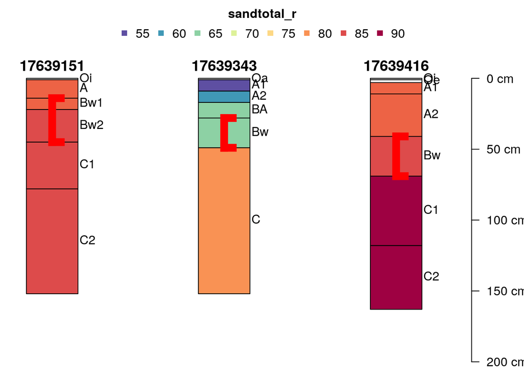

```r
# set margins
par(mar=c(0,1,3,1))

# plot spc using total sand RV % as color
plotSPC(my.spc.sub,
        color='sandtotal_r',
        width=0.15,
        cex.names = 1)

# add red brackets showing cambic horizon top and bottom depth
addDiagnosticBracket(my.spc.sub,
                     kind='Cambic horizon',
                     top='featdept_r',
                     bottom='featdepb_r',
                     col='red',
                     offset=0,
                     lwd=10)
```

Now that we have the data and have done some preliminary inspection, let’s define a regular expression pattern and a function to check our cambic criteria.

Define a custom function `has_sandy_cambic()` to test horizons *within the cambic depth range* for each profile. The default argument `sandy.texture.pattern` matches stratified or sandy textures.

```r
# has_sandy_cambic() has one required argument p, which is a single profile SPC
has_sandy_cambic <- function(p, sandy.texture.pattern = "SR|-S$|^S$|COS$|L[^V]FS$|[^L]VFS$|LS$|LFS$") {
  d <- diagnostic_hz(p)

  # match the pattern cambic or Cambic
  d.cambic.idx <- grep(d$featkind, pattern="[Cc]ambic")
  cambic_top <- d[d.cambic.idx, 'featdept_r']
  cambic_bot <- d[d.cambic.idx, 'featdepb_r']

  # if top or bottom depth are NULL there is no cambic
  if(!is.null(cambic_top) | !is.null(cambic_bot)) {

    # glom horizons in p from cambic_top to cambic_bot
    cambic_horizons <- glom(p, cambic_top, cambic_bot, as.data.frame = TRUE)

    print(paste0("COKEY: ",unique(p$cokey)," has cambic (",
                 cambic_top," - ",cambic_bot," cm) with ", paste0(cambic_horizons$hzname, collapse=","),
                 " horizons of texture class: ", paste0(cambic_horizons$texture, collapse=", ")))

    # use a regular expression to match the sandy textures
    if(any(grepl(cambic_horizons$texture,
                 pattern = sandy.texture.pattern,
                 ignore.case = TRUE))) {
      return(TRUE)
    }
  }
  return(FALSE)
}
```

Apply the function to each profile.

```r
# apply function has_sandy_cambic() to each profile
my.spc.sub$sandy_cambic <- profileApply(my.spc.sub, has_sandy_cambic)
```

```
## [1] "COKEY: 17639151 has cambic (14 - 45 cm) with Bw1,Bw2 horizons of texture class: cb-ls, cbv-lfs"
## [1] "COKEY: 17639343 has cambic (28 - 49 cm) with Bw horizons of texture class: byx-cosl"
## [1] "COKEY: 17639416 has cambic (41 - 69 cm) with Bw horizons of texture class: stv-ls"
```

Inspect results. Print out the offending unique profile IDs (`cokey`).

```r
# do any components have a sandy cambic?
if(any(my.spc.sub$sandy_cambic)) {
  print(paste0("The following components have sandy cambics: ",
        paste0(profile_id(my.spc.sub)[my.spc.sub$sandy_cambic], collapse=",")))
} else {
  print("All components with cambics have appropriate textures.")
}
```

```
## [1] "The following components have sandy cambics: 17639151,17639416"
```

This document is based on `aqp` version 1.19, `soilDB` version 2.5, and `sharpshootR` version 1.5.